# BAZ2B Hap cell line - VSN normalisation

## intensity based filtering

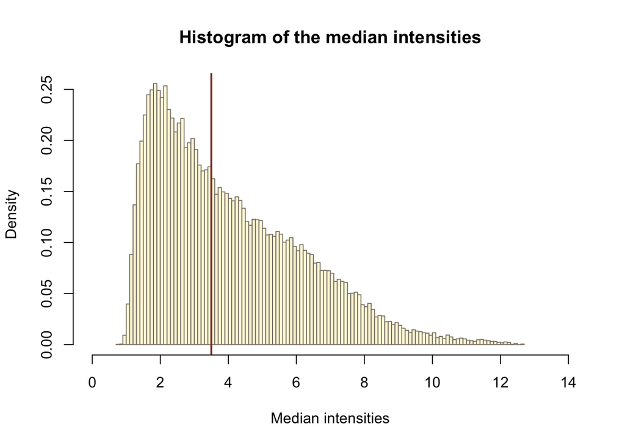

```r
#get medians of IP
rma_medians <- rowMedians(Biobase::exprs(baz2b_del_norm))


  hist_res <- hist(rma_medians, 100, col = "cornsilk1", freq = FALSE,
                 main = "Histogram of the median intensities",
                 border = "antiquewhite4",
                 xlab = "Median intensities", xlim=c(0,14))
  abline(v = 3.5, col = "coral4", lwd = 2)
```

```r
########### filtering intensities higher in at least 2 samples
samples_cutoff <-2


idx_man_threshold <- apply(Biobase::exprs(baz2b_del_norm), 1,
                           function(x){
                             sum(x > 3.5) >= samples_cutoff})
# filterd probes
table(idx_man_threshold)
```

```
## idx_man_threshold
## FALSE  TRUE
## 25895 27722
```

```r
baz2b_del_manfiltered <- subset(baz2b_del_norm, idx_man_threshold)
```

## get gene annotation

convert the probe IDs to human readable genes

```r
anno_baz2b <- AnnotationDbi::select(hugene20sttranscriptcluster.db,
                                       keys =(featureNames(baz2b_del_manfiltered)),
                                       columns = c("ENSEMBL"),
                                       keytype = "PROBEID")
# which Probe-IDs do not have an ENSEMBL accession
table(is.na(anno_baz2b$ENSEMBL))
```

```
##
## FALSE  TRUE
## 27534  9924
```

```r
no_ENSEMBL_ID<-anno_baz2b$PROBEID[(is.na(anno_baz2b$ENSEMBL))]

anno_baz2b <- subset(anno_baz2b, !is.na(ENSEMBL))


# get multimapping ids
anno_grouped <- dplyr::group_by(anno_baz2b, PROBEID)
anno_summarized <-
  dplyr::summarize(anno_grouped, no_of_matches = n_distinct(ENSEMBL))


## merge all gene names of those with multimapping ids
anno_filtered <- filter(anno_summarized, no_of_matches > 1)
probe_stats <- anno_filtered

#number of mult-ID probes and no ENSEMBL
nrow(probe_stats)
```

```
## [1] 2510
```

```r
ids_to_exlude <- (featureNames(baz2b_del_manfiltered) %in% c(probe_stats$PROBEID,
                                                         no_ENSEMBL_ID))
table(ids_to_exlude)
```

```
## ids_to_exlude
## FALSE  TRUE
## 15288 12434
```

```r
## remove multimapper
baz2b_del_final <- subset(baz2b_del_manfiltered, !ids_to_exlude)
validObject(baz2b_del_final)
```

```
## [1] TRUE
```

```r
fData(baz2b_del_final)$PROBEID <- rownames(fData(baz2b_del_final))


fData(baz2b_del_final) <- left_join(fData(baz2b_del_final), anno_baz2b)
nrow(fData(baz2b_del_final))
```

```
## [1] 15288
```

```r
rownames(fData(baz2b_del_final)) <- fData(baz2b_del_final)$PROBEID
validObject(baz2b_del_final)
```

```
## [1] TRUE
```

```r
###### add gene names

anno_baz2b_genes <- AnnotationDbi::select(hugene20sttranscriptcluster.db,
                                       keys =(featureNames(baz2b_del_final)),
                                       columns = c("SYMBOL","GENENAME"),
                                       keytype = "PROBEID")
mx.genes<-match(fData(baz2b_del_final)$PROBEID , anno_baz2b_genes$PROBEID)

fData(baz2b_del_final)<-(data.frame(fData(baz2b_del_final),
                        anno_baz2b_genes[mx.genes,c("SYMBOL","GENENAME")]))
validObject(baz2b_del_final)
```

```
## [1] TRUE
```

## Differential analysis

To identify significant RNA expression changes in RNA Baz2b deleted cells a linear model was fit. The main idea is to fit a linear model to the expression data for each gene. Empirical Bayes and other methods are used to borrow information across genes for the residual variance estimation leading to moderated t-statistics, and stabilizing the analysis for experiments with just a small number of arrays. Conceptually, the final per gene variance is a mix of a prior variance and the per gene variance.

```r
##desig of linear model
pData(baz2b_del_final)
```

```
##                             condition replica
## P193_01_Hap1_wt_P5_1.CEL           wt      R1
## P193_02_Hap1_wt_P6_2.CEL           wt      R2
## P193_04_Hap1_Baz2B_P5_1.CEL   d_Baz2B      R1
## P193_05_Hap1_Baz2B_P6_2.CEL   d_Baz2B      R2
```

```r
design<-model.matrix(~0+factor(c(1,1,2,2)))
colnames(design)<-c( "wt", "d_Baz2b")
fit<-lmFit(baz2b_del_final, design)

contrast.matrix<-makeContrasts(d_Baz2b-wt  ,levels = design)
fit2<-contrasts.fit(fit, contrast.matrix)
fit2<-eBayes(fit2)

expFinal<-exprs(baz2b_del_final)

## d_Baz2b - wt
res.baz2b_del<-topTable(fit2, coef=1, number = Inf , adjust="BH")

# number of significant changes after correction for multiple testing
dt<-(decideTests(fit2,p.value = 0.05))
summary(dt)
```

```
##        d_Baz2b - wt
## Down             63
## NotSig        15189
## Up               36
```

```r
#show the top hits
head(res.baz2b_del)
```

```
##           PROBEID         ENSEMBL      SYMBOL
## 16966809 16966809 ENSG00000134853      PDGFRA
## 17122488 17122488 ENSG00000172965 MIR4435-2HG
## 16942958 16942958 ENSG00000044524       EPHA3
## 16798479 16798479 ENSG00000186297      GABRA5
## 17048190 17048190 ENSG00000058091       CDK14
## 17105706 17105706 ENSG00000185222      TCEAL9
##                                                        GENENAME     logFC
## 16966809          platelet derived growth factor receptor alpha -2.768259
## 17122488                                    MIR4435-2 host gene -2.730162
## 16942958                                        EPH receptor A3 -2.427913
## 16798479 gamma-aminobutyric acid type A receptor alpha5 subunit  2.380759
## 17048190                             cyclin dependent kinase 14 -2.359597
## 17105706               transcription elongation factor A like 9  2.140324
##           AveExpr         t      P.Value    adj.P.Val        B
## 16966809 5.703066 -24.18349 2.369241e-08 0.0001906192 8.482092
## 17122488 5.815162 -24.01596 2.493710e-08 0.0001906192 8.455944
## 16942958 5.491787 -22.32383 4.269161e-08 0.0002175564 8.169462
## 16798479 6.857446  20.81102 7.147843e-08 0.0002731906 7.874337
## 17048190 4.925660 -17.93215 2.125368e-07 0.0006498527 7.184770
## 17105706 6.193697  17.35163 2.701984e-07 0.0006884656 7.021142
```

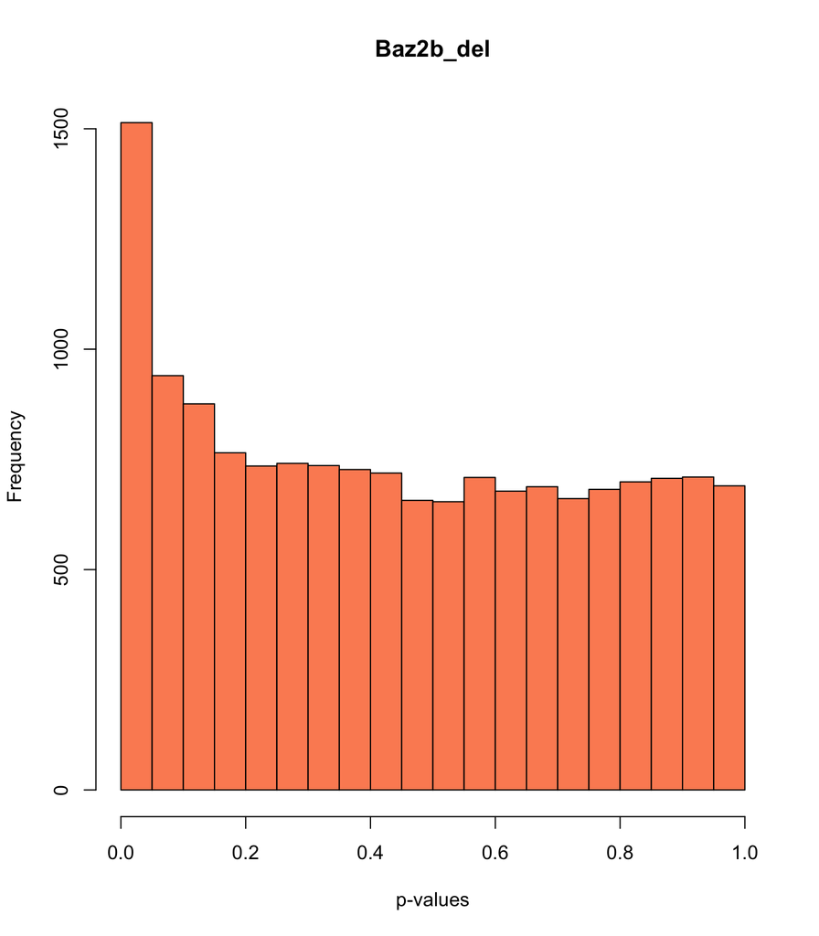

```r
#add probe intensities
res.baz2b_del.ext<-cbind(res.baz2b_del,
                        expFinal[match(res.baz2b_del$PROBEID, rownames(expFinal)),])

## pvalue distribution
 hist(res.baz2b_del$P.Value, col = brewer.pal(3, name = "Set2")[2],
     main = "Baz2b_del", xlab = "p-values")
```

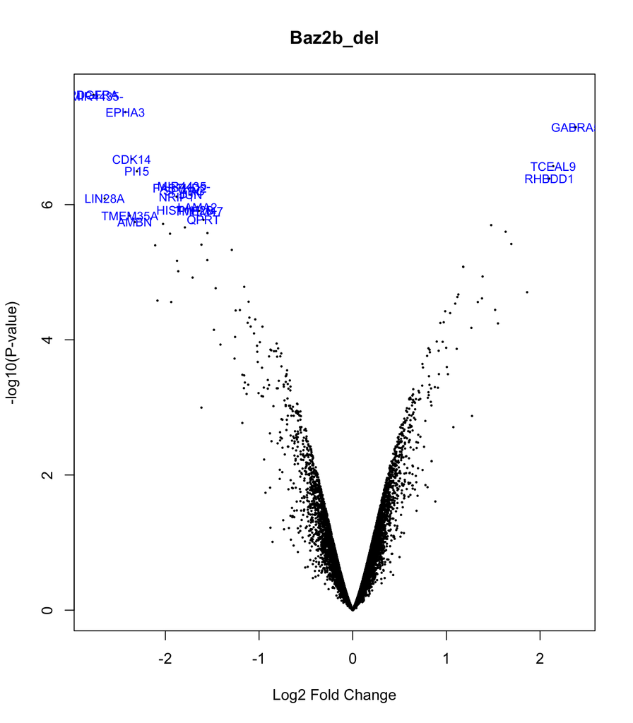

```r
# Volcano plot highlighting the top 20 genes

volcanoplot(fit2, coef = 1, style = "p-value", highlight = 20,
            names = fit2$genes$SYMBOL,
            xlab = "Log2 Fold Change", ylab = NULL, pch=16, cex=0.35, main=
               "Baz2b_del")
```

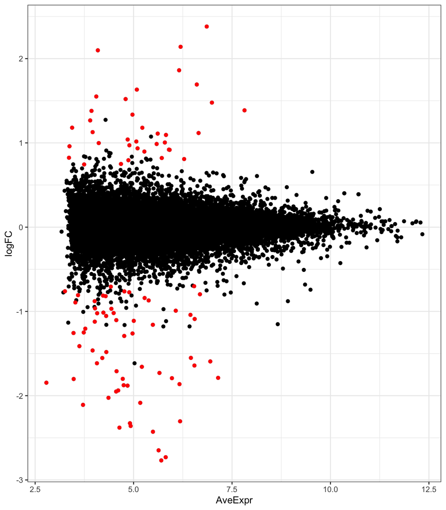

```r
### MA-plot

ggplot(res.baz2b_del.ext, aes(AveExpr,logFC))+geom_point()+
    geom_point(data = subset(res.baz2b_del.ext,  adj.P.Val<0.05), col="red")+
    theme_bw()
```

## Gene ontology (GO) enrichment analysis

We can now try to characterize the identified differentially expressed genes more in detail by performing a GO enrichment analysis.

For every differentially expressed gene, we try to find genes with similar expression with genefinder. The genefinder function returns a list with two elements for each gene: one with the indices of the background genes found and one with the distances to the DE-genes:

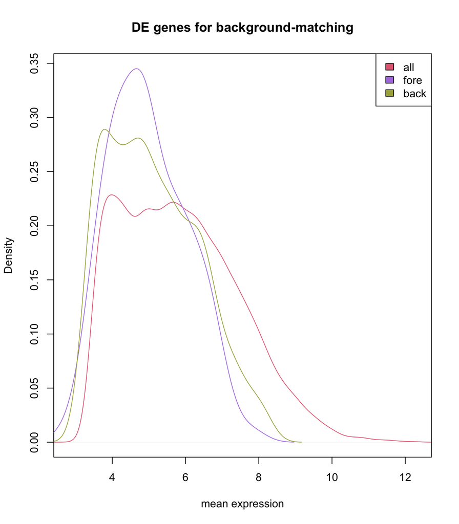

```r
DE_genes<-subset(res.baz2b_del.ext, adj.P.Val < 0.05)$PROBEID

back_genes_idx <- genefilter::genefinder(baz2b_del_final,
                                        as.character(DE_genes),
                                        method = "manhattan", scale = "none")
back_genes_idx <- sapply(back_genes_idx, function(x)x$indices)
back_genes <- featureNames(baz2b_del_final)[back_genes_idx]
back_genes <- setdiff(back_genes, DE_genes)

multidensity(list(
        all = res.baz2b_del.ext[,"AveExpr"] ,
        fore =res.baz2b_del.ext[DE_genes , "AveExpr"],
        back = res.baz2b_del.ext[rownames(res.baz2b_del.ext) %in% back_genes, "AveExpr"]),
        col = c("#e46981", "#ae7ee2", "#a7ad4a"),
     xlab = "mean expression",
   main = "DE genes for background-matching")
```

```r
## running topGO
gene_IDs <- rownames(res.baz2b_del.ext)
in_universe <- gene_IDs %in% c(DE_genes, back_genes)
in_selection <- gene_IDs %in% DE_genes

all_genes <- in_selection[in_universe]
all_genes <- factor(as.integer(in_selection[in_universe]))
names(all_genes) <- gene_IDs[in_universe]

top_GO_data <- new("topGOdata", ontology = "BP", allGenes = all_genes,
 nodeSize = 10, annot = annFUN.db, affyLib = "hugene20sttranscriptcluster.db")
```

```
##
## Building most specific GOs .....
```

```
##  ( 2477 GO terms found. )
```

```
##
## Build GO DAG topology ..........
```

```
##  ( 5981 GO terms and 13868 relations. )
```

```
##
## Annotating nodes ...............
```

```
##  ( 493 genes annotated to the GO terms. )
```

```r
result_top_GO_elim <-
  runTest(top_GO_data, algorithm = "elim", statistic = "Fisher")
```

```
##
##           -- Elim Algorithm --
##
##       the algorithm is scoring 917 nontrivial nodes
##       parameters:
##           test statistic: fisher
##           cutOff: 0.01
```

```
##
##   Level 14:  1 nodes to be scored    (0 eliminated genes)
```

```
##
##   Level 13:  7 nodes to be scored    (0 eliminated genes)
```

```
##
##   Level 12:  20 nodes to be scored   (0 eliminated genes)
```

```
##
##   Level 11:  23 nodes to be scored   (0 eliminated genes)
```

```
##
##   Level 10:  35 nodes to be scored   (0 eliminated genes)
```

```
##
##   Level 9:   56 nodes to be scored   (0 eliminated genes)
```

```
##
##   Level 8:   90 nodes to be scored   (10 eliminated genes)
```

```
##
##   Level 7:   145 nodes to be scored  (34 eliminated genes)
```

```
##
##   Level 6:   179 nodes to be scored  (34 eliminated genes)
```

```
##
##   Level 5:   177 nodes to be scored  (69 eliminated genes)
```

```
##
##   Level 4:   113 nodes to be scored  (157 eliminated genes)
```

```
##
##   Level 3:   52 nodes to be scored   (184 eliminated genes)
```

```
##
##   Level 2:   18 nodes to be scored   (184 eliminated genes)
```

```
##
##   Level 1:   1 nodes to be scored    (184 eliminated genes)
```

```r
result_top_GO_classic <-
  runTest(top_GO_data, algorithm = "classic", statistic = "Fisher")
```

```
##
##           -- Classic Algorithm --
##
##       the algorithm is scoring 917 nontrivial nodes
##       parameters:
##           test statistic: fisher
```

```r
res_top_GO <- GenTable(top_GO_data, Fisher.elim = result_top_GO_elim,
        Fisher.classic = result_top_GO_classic,
        orderBy = "Fisher.elim" , topNodes = 100)

genes_top_GO <- printGenes(top_GO_data, whichTerms = res_top_GO$GO.ID,
    chip = "hugene20sttranscriptcluster.db", geneCutOff = 1000)

res_top_GO$sig_genes <- sapply(genes_top_GO, function(x){
                str_c(paste0(x[x$'raw p-value' == 2, "Symbol.id"],";"),
                      collapse = "")
    })




head(res_top_GO[,1:8], 20)
```

```
##         GO.ID                                        Term Annotated
## 1  GO:0030198           extracellular matrix organization        21
## 2  GO:0009888                          tissue development        84
## 3  GO:0010634 positive regulation of epithelial cell m...        10
## 4  GO:0033993                           response to lipid        37
## 5  GO:1901700      response to oxygen-containing compound        64
## 6  GO:0071363 cellular response to growth factor stimu...        34
## 7  GO:0001654                             eye development        15
## 8  GO:0048562               embryonic organ morphogenesis        15
## 9  GO:0014070         response to organic cyclic compound        35
## 10 GO:0001501                 skeletal system development        19
## 11 GO:2000026 regulation of multicellular organismal d...       102
## 12 GO:0050678 regulation of epithelial cell proliferat...        17
## 13 GO:0071396                  cellular response to lipid        21
## 14 GO:0048646 anatomical structure formation involved ...        47
```

[output cut: 27 more lines]

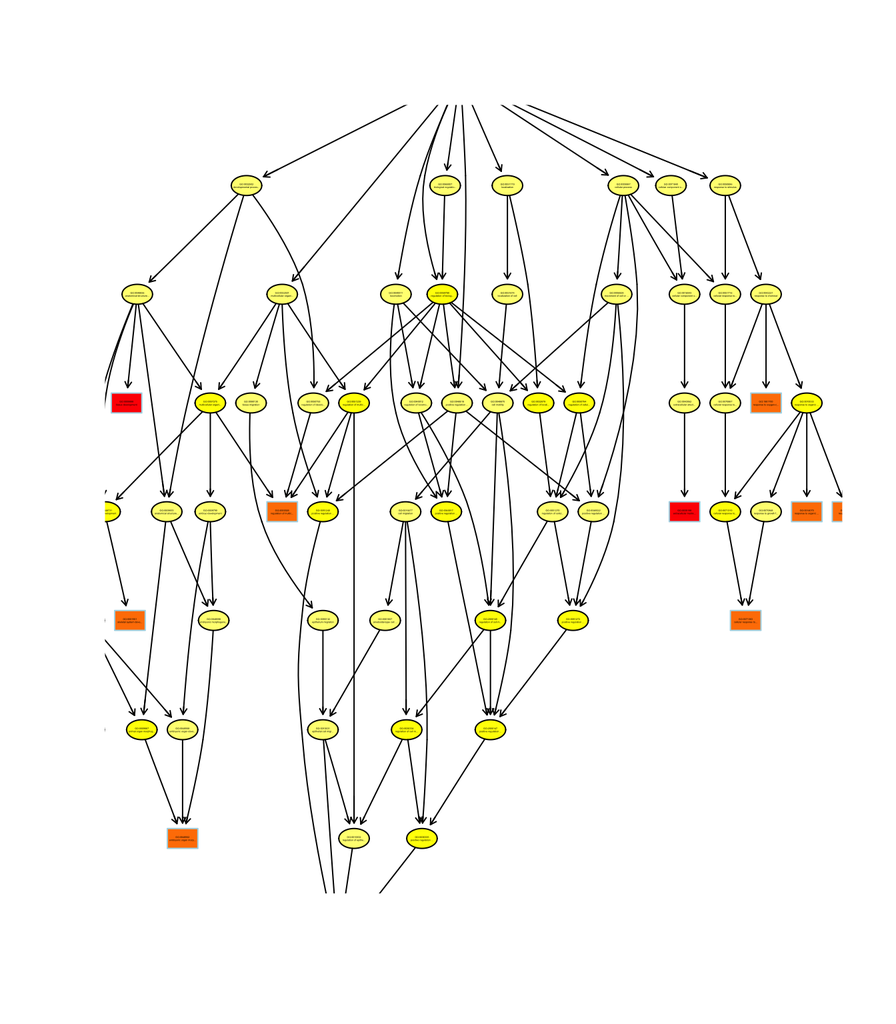

```
## $dag
## A graphNEL graph with directed edges
## Number of Nodes = 65
## Number of Edges = 114
##
## $complete.dag
## [1] "A graph with 65 nodes."
```

```r
numb.sig<-sum(res_top_GO$Fisher.elim<0.01)
showSigOfNodes(top_GO_data, score(result_top_GO_elim), firstSigNodes = numb.sig,
               useInfo = 'def')
```

## Pathway analysis

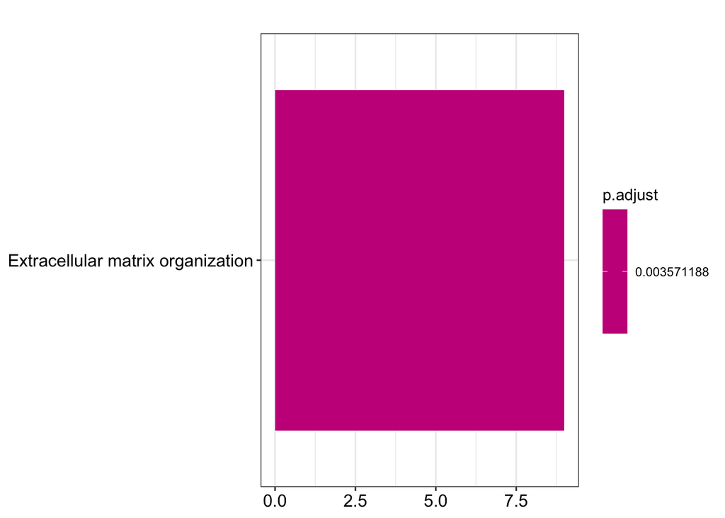

```r
entrez_ids <- mapIds(hugene20sttranscriptcluster.db,
      keys = rownames(res.baz2b_del),
      keytype = "PROBEID",
      column = "ENTREZID")
reactome_enrich <- enrichPathway(gene = entrez_ids[DE_genes],
                                universe = entrez_ids[c(DE_genes,
                                                        back_genes)],
                                organism = "human",
                                pvalueCutoff = 0.05,
                                qvalueCutoff = 0.9,
                                readable = TRUE)


barplot(reactome_enrich)
```